# QMM1002 Case Study 2

Tolulope Ajimoko

2023-12-09

## Introduction

**How does the study hours of Cambrian College’s analytics student across programs compare to each other?** **Are My Study Goals Met?**

This study builds on the first case study to analyze a larger collection of data spanning 2 semesters to provides an insight into my study habits. For this study I analyzed both personalized data and aggregrated data for Analytics students in BAPG, CAGC, or HAGC programs at Cambriam College. I collected personalized data daily for different variables over 201 days from 21st May 2023 to 7th December 2023 to analyze if I am keeping up with my study goals. The variables I collected for this study are described below:

| Variable | Type |
| --- | --- |
| Date | Identifier |
| Hours in Class | Quantitative (Number of hours spent attending class on zoom or watching Zoom recording) |
| Hours Studiying | Quantitative (Number of hours spent on schoolwork, excluding time spent watching attending class on zoom or watching Zoom recording) |
| Hours Sleeping | Quantitative (Number of hours spent sleeping) |
| Cups of Water | Quantitative (Number of cups of water drank) |
| Watch the News (Y/N) | Categorical (Number of hours spent watching the news) |
| Type of Exercise | Categorical (The type of exercise done) |
| Intensity of Exercise (H/M/L) | Categorical (Intensity of the exercise carried out) |
| Time Spent Exercising (mins) | Quantitative (Number of minutes spent exercising) |
| Term | Categorical (Categorizes the datapoints as either Summer or Fall semesters) |

The aggregrated data also was also collected for the Analytics students on the Date, Hours Studiying, Semester, and Program variables.

#### Summary Statistics

```r
personalized<-read.csv(file="Ajimoko_Tolulope_Personalized_Data.csv", header=TRUE)
personalized.studymean<-mean(personalized$Study, na.rm=TRUE)
personalized.studysd<-sd(personalized$Study, na.rm=TRUE)
#mean(students$Study, Program==BAPG, na.rm=TRUE)

students<-read.csv(file="Combined.csv", header=TRUE, fileEncoding="UTF-8-BOM")
BAPG.mean <- mean(students$Study[students$Program == "BAPG"], na.rm = TRUE)
BAPG.sd <- sd(students$Study[students$Program == "BAPG"], na.rm = TRUE)

CAGC.mean <- mean(students$Study[students$Program == "CAGC"], na.rm = TRUE)
CAGC.sd <- sd(students$Study[students$Program == "CAGC"], na.rm = TRUE)

HAGC.mean <- mean(students$Study[students$Program == "HAGC"], na.rm = TRUE)
HAGC.sd <- sd(students$Study[students$Program == "HAGC"], na.rm = TRUE)
```

| Data Set | Mean | Standard Deviation |
| --- | --- | --- |
| personal | 3.182266 | 1.570546 |
| All Students | 3.5666611 | 2.3061209 |
| BAPG | 3.3382567 | 2.2996478 |
| CAGC | 4.079602 | 2.545816 |
| HAGC | 3.8118149 | 2.1271117 |

The purpose of this study is to answer the following questions:

1. Are there differences in the average study times for students in the different programs?
2. Is the distribution of days studied more than 3.13 hours (the average daily study time for students at McGill) the same for students in the different programs (i.e. are the noumber of hours studies by the students independent of program)?
3. How does my personal study time change over the two semesters?

These questions will be answered by analyzing the ‘Hours Spent Studying’ and ‘Term’ variables by performing the following statistical analysis:

1. Performing ANOVA test to determine if there is a differences in the average study times for students in the different programs
2. Performing the Chi-square test to determine if the distribution of days studied more than 3.13 hours is the same for students in the different programs
3. Performing a Time Series Analysis to find out how my personal study time has changed. At the end of the study, I will be able to find out how my studying has varied over time and how analytics students have been studying.

## Analysis

### Part 1: ANOVA Test

```r
# Installing packages
options(repos = c(CRAN = "https://cran.r-project.org"))
install.packages("dplyr", quiet = TRUE)
install.packages("car", quiet = TRUE)
library(dplyr)
library(car)
```

#### Stating Hypothesis

##### Null and alternative hypothesis

$H_0: \muBAPG=\muCAGC=\muHAGC$  
$H_A:$ At least one mean in different

#### Preparing the Data for analysis

```r
# creating subsets
BAPG <- subset(students, select=c("Program", "Study"), Program == "BAPG")
CAGC <- subset(students, select=c("Program", "Study"), Program == "CAGC")
HAGC <- subset(students, select=c("Program", "Study"), Program == "HAGC")

# selecting 50 random samples from each group
set.seed(123)
BAPG_sample <- BAPG %>% sample_n(50)
CAGC_sample <- CAGC %>% sample_n(50)
HAGC_sample <- HAGC %>% sample_n(50)

# combining the samples
analytics <- bind_rows(BAPG_sample, CAGC_sample, HAGC_sample)
```

#### Performing the ANOVA test

```r
analytics.anova<-aov(Study~Program, analytics)
summary(analytics.anova)
```

```
##              Df Sum Sq Mean Sq F value Pr(>F)
## Program       2   27.5  13.743   2.814 0.0632 .
## Residuals   147  717.8   4.883
## ---
## Signif. codes:  0 '***' 0.001 '**' 0.01 '*' 0.05 '.' 0.1 ' ' 1
```

p-value = 0.063 which is greater that alpha of 0.05

**Decision**  
We fail to reject the null hypothesis

**Interpretation**  
There is no substantial evidence that at least one mean is different. i.e. not enough evidence that the number of hours studied is the different across programs.

#### Checking if the conditions required for using ANOVA are met

**Randomization and Independence Assumption**  
The samples were randomly selected and the data for one day does not affect the data for another day.

**Equal Variance Assumption**

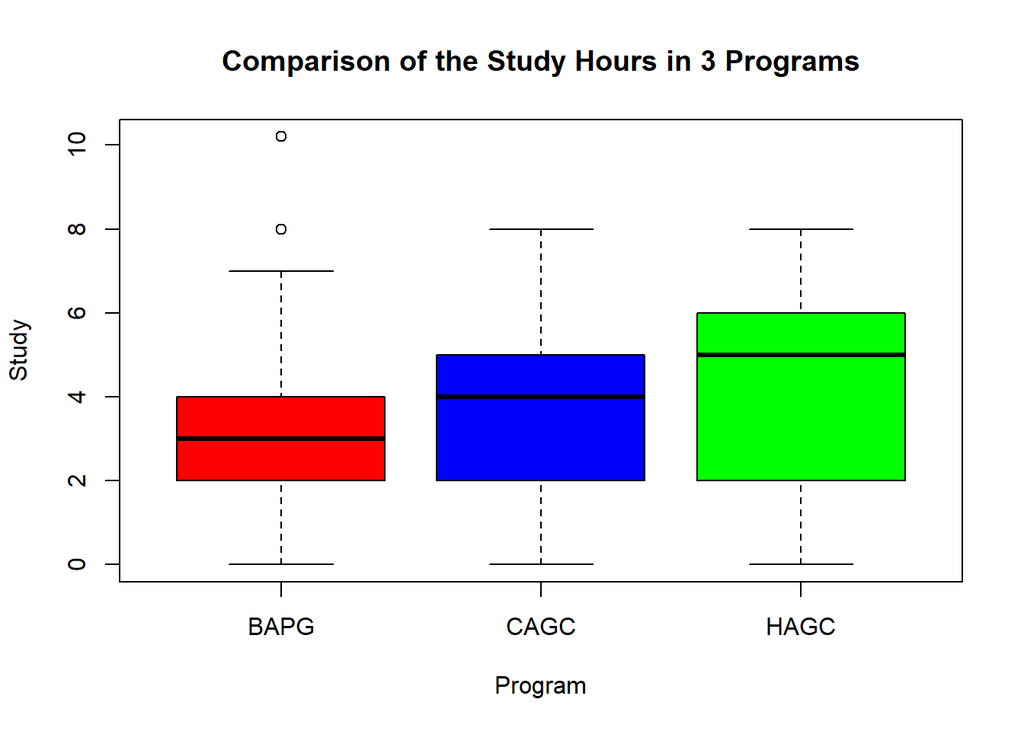

```r
boxplot(Study~Program, analytics, main="Comparison of the Study Hours in 3 Programs", col=c("red", "blue", "green" ))
```

The variance are somewhat similar in range. Although BAPG has a tight variance and some outliers. However the difference is not outrageous so we accept that the equal variance assumption is met

*Nearly Normal Population*

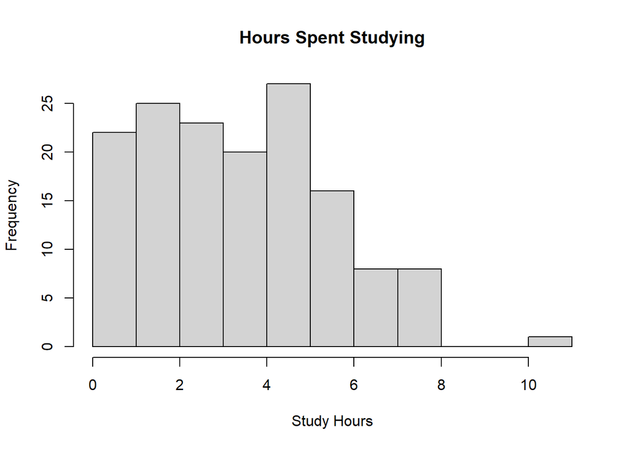

```r
hist(analytics$Study, xlab="Study Hours", main="Hours Spent Studying")
```

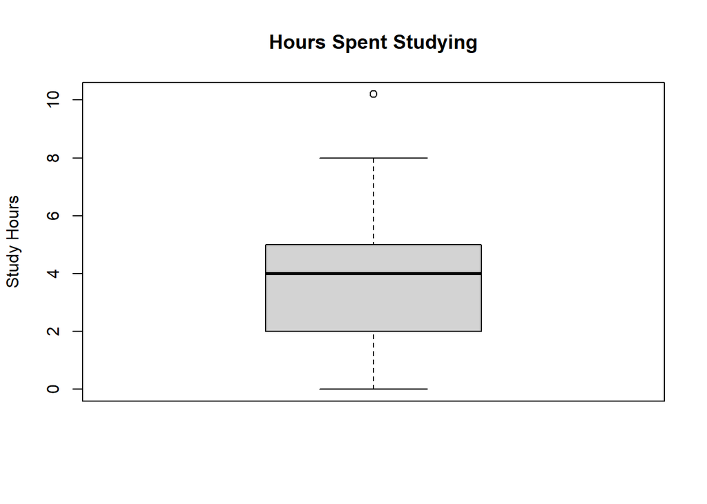

```r
boxplot(analytics$Study, ylab="Study Hours", main="Hours Spent Studying")
```

This histogram is right skewed and the boxplot has an outlier, howerver the skewness is not outrageous. We will accept that the nearly normal condition is met for the purpose of this study.